# ggplot2: 3 Individual Geoms

This notebook is based on exercises completed from [ggplot2: Elegant Graphics for Data Analysis](https://ggplot2-book.org/index.html).

```r
library(tidyverse)

# set global theme for graphs
theme_set(theme_bw())
```

#3.1.1 Individual Geoms Exercises

1. What geoms would you use to draw each of the following named plots?

1.Scatterplot - geom_point() 2.Line chart - geom_line 3.Histogram - geom_histogram() 4.Bar chart - geom_bar(stat = “identity”) 5.Pie chart - geom_bar() + coord_polar() see example

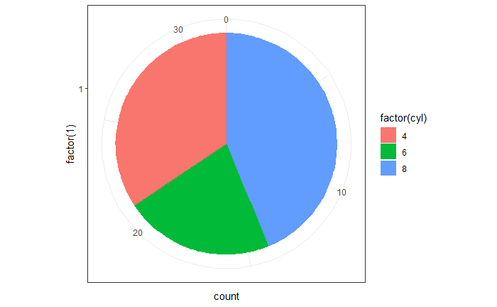

```r
# from https://ggplot2.tidyverse.org/reference/coord_polar.html
pie <-
  ggplot(mtcars, aes(x = factor(1), fill = factor(cyl))) +
  geom_bar(width = 1)

pie + coord_polar(theta = "y")
```

2. What’s the difference between geom_path() and geom_polygon()? What’s the difference between geom_path() and geom_line()?

-geom_path draws a line in the order of the data whereas geom_polygon fills in the area between lines

-geom_path draws the line in the order of the data whereas geom_line draws from left to right

3. What low-level geoms are used to draw geom_smooth()? What about geom_boxplot() and geom_violin()?

-geom_smooth uses geom_line for the best fit line and geom_area for the standard error shading  
-geom_boxplot uses geom_rect or geom_tile or geom_area  
-geom_violin uses geom_polygon or geom_hist (sideways)